# Community Composition & Diversity from a Phyloseq Object

Jonathan Rondeau-Leclaire

2026-10-26

**About this tutorial**

Once you have a `phyloseq` object (ASV/OTU table + taxonomy + sample metadata, all linked together), three analyses come up again and again: a **composition barplot** (relative abundance by taxonomic rank), an **alpha diversity** comparison (within-sample diversity across groups), and a **beta diversity** ordination (between-sample dissimilarity, e.g. a PCoA). This tutorial builds all three, one at a time, from the same publicly available phyloseq object. To build your own phyloseq object from DADA2 outputs, see the post-processing tutorial.

It’s adapted from a real analysis script, [`5.2_Figs3_4_5_Plots_byCity.R`](https://github.com/jorondo1/urban_bioaerosols/blob/main/scripts/5.2_Figs3_4_5_Plots_byCity.R), which builds a publication-grade multi-panel figure, published in STOTEN by [Poirier S., Rondeau-Leclaire J., et al 2026](https://www.sciencedirect.com/science/article/pii/S0048969726002846). That version relies on more advanced coding, so we’re going to do a simplified version of one of these plots.

# 1 Setup

```r
library(pacman)
p_load(mgx.tools, # devtools::install_github("jorondo1/mgx.tools")
       tidyverse, phyloseq, RColorBrewer, vegan, rstatix, ggpubr, kableExtra, knitr)
```

`mgx.tools` is the same in-house package used in the DADA2 tutorial; a couple of its small utilities (`samdat_as_tibble()`) show up below.

## 1.1 Download a toy dataset

If you don’t have your own data, you can use this one from `Poirier et al. 2026`. The file actually contains three datasets: bacteria, fungi, and plant particles, pre-processed and rarefied to even sequencing depth.

```r
poirier_data <- read_rds('https://raw.githubusercontent.com/jorondo1/urban_bioaerosols/main/data/ps_rare.ls.rds')
ps_fung <- poirier_data$FUNG
ps_fung
```

```
## phyloseq-class experiment-level object
## otu_table()   OTU Table:         [ 1348 taxa and 148 samples ]
## sample_data() Sample Data:       [ 148 samples by 35 sample variables ]
## tax_table()   Taxonomy Table:    [ 1348 taxa by 7 taxonomic ranks ]
```

A phyloseq object bundles three tables together (the ASV/OTU count table, the taxonomy table, and the sample metadata) and keeps them aligned. Pull out just the sample metadata as a tibble, which is all we need to see what we can group by:

```r
samdat_as_tibble(ps_fung) %>%
  select(Sample, city, time, date) %>%
  head()
```

```
## # A tibble: 6 × 4
##   Sample       city     time  date
##   <fct>        <fct>    <fct> <date>
## 1 22-A-MTL-01A Montreal Fall  2022-09-04
## 2 22-A-MTL-02A Montreal Fall  2022-09-04
## 3 22-A-MTL-03A Montreal Fall  2022-09-09
## 4 22-A-MTL-04A Montreal Fall  2022-09-03
## 5 22-A-MTL-05B Montreal Fall  2022-09-03
## 6 22-A-MTL-06C Montreal Fall  2022-09-04
```

Three sampling cities (`city`), three sampling periods (`time`: Spring/Summer/Fall), each spread across a handful of `date`s. We’ll aggregate across `date`, keeping only `city` and `time`.

If you have your own data, you can adapt the code below to your own variables, depending on which metadata categories you want to show separately.

# 2 Relative abundance plots

**Objective:** plot the mean relative abundance for each season within each city, while showing only the top 12 taxa and bundling the rest in an “Others” category.

## 2.1 Melt the phyloseq object

`psmelt()` turns a phyloseq object into one long-format table, one row per ASV × sample, with the taxonomy and sample metadata already joined in.

```r
melted_ps <- psflashmelt(ps_fung)
dim(melted_ps)
```

```
## [1] 199504     45
```

You can peak into it using `View(melted_ps)` on RStudio, you’ll see it’s quite a large data frame! Let’s tidy it up for ggplot.

## 2.2 Mean relative abundances

Pick the taxonomic rank you want to plot, e.g. `Genus`, and aggregate every ASV within each **sample** down to its `Genus`, then normalize within each sample before averaging into `city`/`time` groups:

```r
relab_df <- melted_ps %>%

  # Summarise at desired rank:
  group_by(Sample, city, time, Genus) %>%  # unspecified variables will be dropped!
  summarise(Abundance = sum(Abundance), .groups = 'drop') %>%

  # compute relative abundances:
  group_by(Sample) %>%
  mutate(relAb = Abundance / sum(Abundance)) %>%

  # compute mean relative abundance by city X time combinations for each Genus:
  group_by(city, time, Genus) %>%
  summarise(relAb = mean(relAb), .groups = 'drop') %>%

  # only keep non-zero rows:
  filter(relAb>0)
```

```r
# Replace NAs with "Unclassified" throughout:
relab_df <- relab_df %>%
  mutate(replace(Genus, is.na(Genus), "Unclassified"))

relab_df
```

```
## # A tibble: 1,812 × 5
##    city     time  Genus              relAb replace(Genus, is.na(Genus), "Uncla…¹
##    <fct>    <fct> <chr>              <dbl> <chr>
##  1 Montreal Fall  Agrocybe       0.000190  Agrocybe
##  2 Montreal Fall  Allophoma      0.0000635 Allophoma
##  3 Montreal Fall  Alternaria     0.0393    Alternaria
##  4 Montreal Fall  Alutaceodontia 0.00137   Alutaceodontia
##  5 Montreal Fall  Amphinema      0.00157   Amphinema
##  6 Montreal Fall  Amylocorticium 0.000175  Amylocorticium
##  7 Montreal Fall  Amyloporia     0.00198   Amyloporia
##  8 Montreal Fall  Amylostereum   0.0000317 Amylostereum
##  9 Montreal Fall  Antrodiella    0.00827   Antrodiella
## 10 Montreal Fall  Apenidiella    0.0000476 Apenidiella
## # ℹ 1,802 more rows
## # ℹ abbreviated name: ¹`replace(Genus, is.na(Genus), "Unclassified")`
```

We normalize **within each sample first** (`relAb = Abundance / sum(Abundance)`, grouped by `Sample`), then average those proportions across every sample in a `city`/`time` group. This matters whenever samples don’t all have the same sequencing depth: without it, a sample with 200,000 reads would dominate the group average over one with 20,000 reads, even if they’re biologically equivalent.

If your phyloseq object is already **rarefied** to even depth (as this one is), every sample already carries equal weight, so you can skip the per-sample step and just sum raw abundances directly within `city`/`time` and normalize once — same result, one less `group_by()`.

## 2.3 Create “Others” category

`relab_df` has 366 distinct genera, wayyy too many for a readable legend. `forcats::fct_lump_n()` keeps the `n` highest-weighted levels and lumps everything else into a single `"Other"` category. We’ll plot 12 genera.

```r
relab_df <- relab_df %>%
  mutate(Genus = fct_lump_n(Genus, n = 12, w = relAb, other_level = "Other")) %>%
  group_by(city, time, Genus) %>%
  summarise(relAb = sum(relAb), .groups = 'drop')

relab_df
```

```
## # A tibble: 99 × 4
##    city     time  Genus           relAb
##    <fct>    <fct> <fct>           <dbl>
##  1 Montreal Fall  Alternaria   0.0393
##  2 Montreal Fall  Bjerkandera  0.00441
##  3 Montreal Fall  Cerrena      0.000841
##  4 Montreal Fall  Cladosporium 0.416
##  5 Montreal Fall  Cortinarius  0.0164
##  6 Montreal Fall  Fomes        0.000349
##  7 Montreal Fall  Fomitopsis   0.0114
##  8 Montreal Fall  Irpex        0.00106
##  9 Montreal Fall  Ramularia    0.000349
## 10 Montreal Fall  Resinicium   0.00617
## # ℹ 89 more rows
```

## 2.4 Plot tweaks [optional]

Two small tweaks make for a nicer plot: order `time` chronologically instead of alphabetically, and order `Genus` alphabetically too, throwing `"Unclassified"` and `"Other"` at the end of the list. You can adapt this to whatever data you have, because usually we want to present our categories in a certain order, and R doesn’t know what order that is.

```r
genus_levels <- levels(relab_df$Genus)
# keep whichever of these two are actually present, in this order:
special_levels <- intersect(c("Unclassified", "Other"), genus_levels)
ordered_levels <- c(sort(setdiff(genus_levels, special_levels)), special_levels)

relab_df <- relab_df %>%
  mutate(
    time  = factor(time, levels = c("Spring", "Summer", "Fall")),
    Genus = factor(Genus, levels = ordered_levels)
  )
```

Since we might end up showing more taxa than a Brewer palette can offer (`RColorBrewer` palettes top out at 12 colours), we expand one by interpolating between its colours.

```r
taxa_pal <- colorRampPalette(brewer.pal(9, "Set1"))(nlevels(relab_df$Genus))
taxa_pal
```

```
##  [1] "#E41A1C" "#705C84" "#3E8E93" "#4DAF4A" "#7E6E85" "#BA5E6C" "#FF7F00"
##  [8] "#FFD421" "#E1C62F" "#A65628" "#DB728C" "#D789B2" "#999999"
```

You can also build your own palette, obviously! Or even modify that one.

```r
taxa_pal[13] <- "grey80" # (12+1)th position is "Others"
taxa_pal[12] <- "grey50" # 12th position is Unclassified
```

## 2.5 Plot !

We’ll put `time` on the x-axis, and facet our plot to have one panel per `city`. You can do other designs, lookup the doc for `facet_wrap()` and `facet_grid()`.

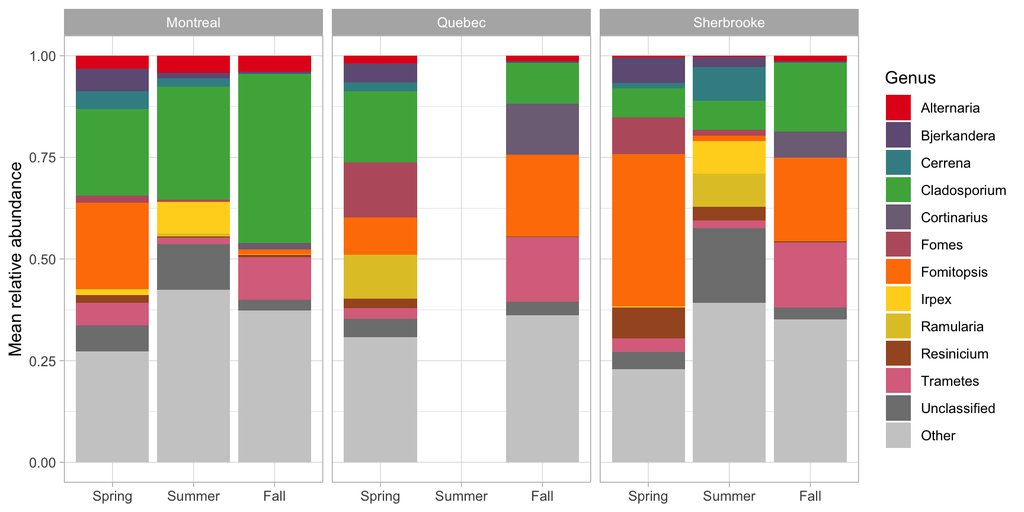

```r
relab_plot <- ggplot(relab_df, aes(x = time, y = relAb, fill = Genus)) +
  geom_col(position = "stack") +
  facet_grid(~city) +
  scale_fill_manual(values = taxa_pal) +
  labs(x = NULL, y = "Mean relative abundance", fill = "Genus") +
  theme_light()

relab_plot
```

**What if I want to show more categories?**

If you had a third variable (let’s call it `condition`), one way to modify that plot would be to add it to the faceting variables, e.g. `facet_grid(condition~city)`. You would still get one column-faceting by city, but also one row-faceting by condition now; the y axis would appear as many times as you have conditions.

Notice the empty Quebec-Summer panel: there’s no data for that combination. By default, `facet_grid()` will show it, empty. If you wanted to hide it, you could add the parameted `scales = 'free_x'` so each panel will only contain the x values for which it has data; it really depends on your goal.

**Sanity check!**

Imagine you needed add a third grouping variable to the data code above (say, `date`). But you forgot to add that variable to the plot! `relab_df` would then have *more than one row* per `city`/`time`/`Genus`, which would add up to more than one. To double-check the data is fine,

```r
# 1. Exactly one row per (city, time, Genus)? This should return 0 rows.
relab_df %>% count(city, time, Genus) %>% filter(n > 1)
```

```
## # A tibble: 0 × 4
## # ℹ 4 variables: city <fct>, time <fct>, Genus <fct>, n <int>
```

```r
# 2. Does every bar actually sum to 1?
relab_df %>% group_by(city, time) %>% summarise(total = sum(relAb), .groups = 'drop')
```

```
## # A tibble: 8 × 3
##   city       time   total
##   <fct>      <fct>  <dbl>
## 1 Montreal   Spring     1
## 2 Montreal   Summer     1
## 3 Montreal   Fall       1
## 4 Quebec     Spring     1
## 5 Quebec     Fall       1
## 6 Sherbrooke Spring     1
## 7 Sherbrooke Summer     1
## 8 Sherbrooke Fall       1
```

To make sure you don’t miss it, use `position = "stack"` (the default for `geom_col()`, spelled out here on purpose) which **sums** every row sharing an `x`/`fill` pair rather than hiding them.

## 2.6 Export output

```r
ggsave(relab_plot, "community_composition.pdf", bg = 'white',
       width = 2400, height = 2000, units = 'px', dpi = 220)
```

# 3 Alpha diversity

Alpha diversity is diversity *within* a sample: how many ASVs there are, and how evenly they’re distributed. We’ll use the Shannon index, a very commonly reported index in microbiome research, and compare it across seasons, within each city.

## 3.1 Rarefy

According to the latest research ([Schloss, 2024](https://journals.asm.org/doi/10.1128/msphere.00354-23)), diversity indices needs to be rarefied to the same sequencing depth to be comparable. Otherwise, a deeper sample could look “more diverse” simply because it was sequenced more.

```r
set.seed(1) # for reproducibility
ps_fung_rare <- rarefy_even_depth(ps_fung, rngseed = 1)
```

This toy dataset is already rarefied, so the step above changes nothing really. Yours might not be!

Actually, ideally we’d also rarefy *many* times and average each index across iterations, since any single random draw can be unlucky; `mgx.tools::rarefy_diversity()` does exactly that (and much more), but requires a lot of processing time.

## 3.2 Compute diversity

`mgx.tools::estimate_diversity()` computes the index you want directly from a phyloseq object, generating one value per sample.

```r
shannon_df <- mgx.tools::estimate_diversity(ps_fung_rare, "Shannon") %>%
  enframe(name = "Sample", value = "Shannon")
```

To create a plot-friendly data frame, we’ll extract our `sample_data` from the phyloseq object and add this Shannon column to it.

```r
alpha_df <- mgx.tools::samdat_as_tibble(ps_fung_rare) %>%
  select(Sample, city, time) %>%
  left_join(shannon_df, by = "Sample") %>%
  mutate(time = factor(time, levels = c("Spring", "Summer", "Fall")))

alpha_df
```

```
## # A tibble: 148 × 4
##    Sample       city     time  Shannon
##    <chr>        <fct>    <fct>   <dbl>
##  1 22-A-MTL-01A Montreal Fall     4.51
##  2 22-A-MTL-02A Montreal Fall     3.56
##  3 22-A-MTL-03A Montreal Fall     3.71
##  4 22-A-MTL-04A Montreal Fall     3.81
##  5 22-A-MTL-05B Montreal Fall     3.97
##  6 22-A-MTL-06C Montreal Fall     2.57
##  7 22-A-MTL-07A Montreal Fall     2.16
##  8 22-A-MTL-09B Montreal Fall     2.83
##  9 22-A-MTL-10A Montreal Fall     4.20
## 10 22-A-MTL-11B Montreal Fall     2.32
## # ℹ 138 more rows
```

For alternative indices, `estimate_diversity()` currently supports Richness, Shannon, Simpson or Tail. If you are interested in Hill numbers, Hill order 1 is `exp(Shannon)` and Hill order 2 is `1/Simpson`; you can create them using `mutate()`.

## 3.3 Plot !

Let’s make a violin plot !

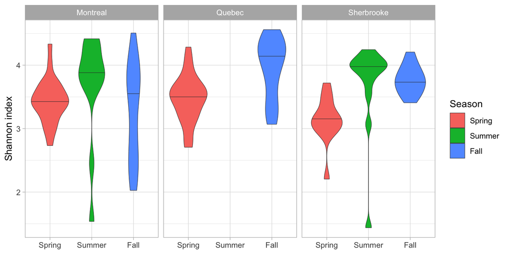

```r
alpha_plot <- alpha_df %>%
  ggplot(aes(x = time, y = Shannon, fill = time)) +
  geom_violin(linewidth = 0.2, draw_quantiles = 0.5) +
  facet_grid(~city) +
  labs(x = NULL, y = "Shannon index", fill = "Season") +
  theme_light()
alpha_plot
```

## 3.4 Wilcoxon tests

We use `rstatix::wilcox_test()` to run one test per pair of seasons, per group (here, `city`). `adjust_pvalue()` then corrects those p-values (Benjamini-Hochberg, i.e. false discovery rate).

```r
alpha_stats <- alpha_df %>%
  group_by(city) %>%
  wilcox_test(Shannon ~ time) %>%
  adjust_pvalue(method = "BH") %>%
  add_significance("p.adj")

alpha_stats
```

```
## # A tibble: 7 × 10
##   city    .y.   group1 group2    n1    n2 statistic       p   p.adj p.adj.signif
##   <fct>   <chr> <chr>  <chr>  <int> <int>     <dbl>   <dbl>   <dbl> <chr>
## 1 Montre… Shan… Spring Summer    24    12        70 1.21e-2 2.12e-2 *
## 2 Montre… Shan… Spring Fall      24    24       296 8.78e-1 8.78e-1 ns
## 3 Montre… Shan… Summer Fall      12    24       198 7.23e-2 1.01e-1 ns
## 4 Quebec  Shan… Spring Fall      25    25       139 5.53e-4 1.94e-3 **
## 5 Sherbr… Shan… Spring Summer    12    13        21 1.23e-3 2.87e-3 **
## 6 Sherbr… Shan… Spring Fall      12    13         9 3.73e-5 2.61e-4 ***
## 7 Sherbr… Shan… Summer Fall      13    13       107 2.64e-1 3.08e-1 ns
```

Note: This test only serves to compare a numerical variable between categories!

Notice that these only test **within city**, not between cities! This is what `group_by()` serves.

Package it as an html table:

```r
alpha_kable <- alpha_stats %>%
  select(city, group1, group2, p, p.adj, p.adj.signif) %>%
  kable(caption = "Wilcoxon rank-sum test: Shannon diversity by season, within each city (BH-adjusted)") %>%
  kable_styling(full_width = FALSE)

alpha_kable
```

Table 3.1: Table 3.2: Wilcoxon rank-sum test: Shannon diversity by season, within each city (BH-adjusted)

city

group1

group2

p

p.adj

p.adj.signif

Montreal

Spring

Summer

0.0121145

0.0212004

Montreal

Spring

Fall

0.8782447

0.8782447

ns

Montreal

Summer

Fall

0.0722648

0.1011707

ns

Quebec

Spring

Fall

0.0005532

0.0019361

Sherbrooke

Spring

Summer

0.0012303

0.0028707

Sherbrooke

Spring

Fall

0.0000373

0.0002611

***

Sherbrooke

Summer

Fall

0.2642111

0.3082463

ns

Or add it to the plot! `rstatix::add_xy_position()` reuses `alpha_stats` directly to work out where each bracket should sit (and which two `time` levels it spans), and `ggpubr::stat_pvalue_manual()` draws it — `city` being a column of `alpha_stats` is what lets it land brackets in the right facet panel. `hide.ns = TRUE` skips drawing a bracket for the non-significant comparisons.

```r
alpha_stats_pos <- alpha_stats %>% add_xy_position(x = "time")

alpha_plot <- alpha_plot +
  stat_pvalue_manual(alpha_stats_pos, label = "p.adj.signif", hide.ns = TRUE)
```

## 3.5 Export output

```r
save_kable(alpha_kable, "alpha_wilcox.html")
ggsave(alpha_plot, "alpha_div.pdf", bg = 'white',
       width = 2200, height = 2000, units = 'px', dpi = 220)
```

`save_kable()` writes the table out as a standalone `.html` file you can share or embed elsewhere. It’s also easy to copy from, to paste into Word Office for example.

# 4 Beta diversity

Beta diversity compares dissimilarity *between* samples. We’ll compute Bray-Curtis distance on variance-stabilized counts, visualize it with a PCoA, and test it with a PERMANOVA.

## 4.1 Rarefaction and VST

```r
set.seed(1)
ps_fung_rare <- rarefy_even_depth(ps_fung, rngseed = 1)
```

Same caveat as for alpha diversity: one rarefaction draw here for simplicity, `mgx.tools::rarefy_diversity()` for the iterate-and-average version.

## 4.2 Compute diversity

`mgx.tools::compute_pcoa()` does many things in one call: 1. computes a distance/dissimilarity matrix using the metric of your choice 2. run classical multidimensional scaling (PCoA) to get 2D coordinates

Optionally, for Bray-Curtis dissimilarities, we variance-stabilize the counts using DESeq2’s VST: handles the mean-variance relationship in count data better than a plain log-transform. To do that, add `vst = TRUE` as below:

```r
bray_pcoa <- compute_pcoa(ps_fung_rare, dist = "bray", vst = TRUE)
names(bray_pcoa)
```

```
## [1] "metadata" "eig"      "dist.mx"
```

It returns a list: `metadata` (sample data with two `PCo1`/`PCo2` columns added, for plotting), `eig` (eigenvalues, for the % variance explained by each axis, which we’ll add to the plot), and `dist.mx` (the distance matrix itself — we’ll need it for the PERMANOVA below).

## 4.3 Plot the PCoA

Prep the data:

```r
# Dataset levels:
pcoa_df <- bray_pcoa$metadata %>%
  mutate(time = factor(time, levels = c("Spring", "Summer", "Fall")))

# One decimal is enough for the PCo contribution %:
eig_pct <- round(100 * bray_pcoa$eig[1:2] / sum(bray_pcoa$eig), 1)
```

Plot !

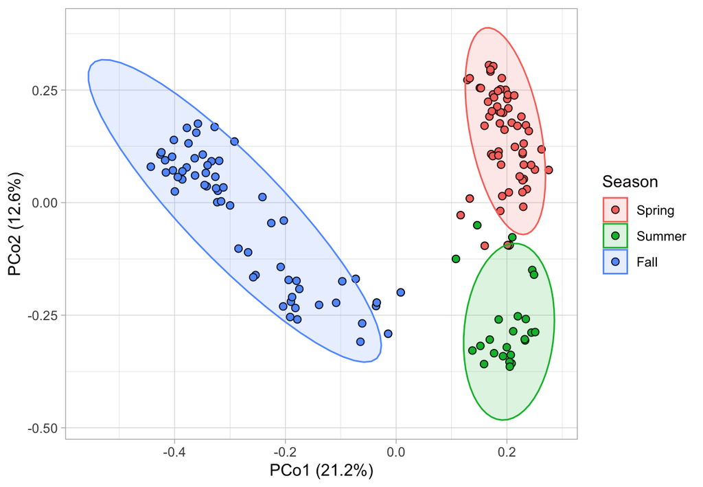

```r
beta_plot <- pcoa_df %>%
  ggplot(aes(x = PCo1, y = PCo2, colour = time, fill = time)) +
  geom_point(size = 2, shape = 21, colour = 'black') +
  stat_ellipse(geom = "polygon", alpha = 0.15, level = 0.95) +

  # Add the axis PCo % contribution
  labs(x = paste0("PCo1 (", eig_pct[1], "%)"),
       y = paste0("PCo2 (", eig_pct[2], "%)"),
       colour = "Season", fill = "Season") +
  theme_light()
beta_plot
```

Samples separate cleanly by season here, We have a strong beta diversity signal. PERMANOVA below tests this formally. You could just as easily colour or facet by `city` instead.

NOTE: if you wanted to show one PCoA per city, don’t simply split `bray_pcoa$metadata` in three. You should be doing one independent PCoA per city.

## 4.4 PERMANOVA

`vegan::adonis2()` tests whether group membership explains a significant share of the distance matrix. We model both `city` and `time` (season), see which variable explains the most variance in beta diversity.

```r
set.seed(1)
permanova <- adonis2(
  bray_pcoa$dist.mx ~ city + time,  # the linear model
  data = bray_pcoa$metadata,        # the dataset
  permutations = 999,               # the precision of p-values
  by = "margin")                     # how the model should be handled (read on that!)
permanova
```

```
## Permutation test for adonis under reduced model
## Marginal effects of terms
## Permutation: free
## Number of permutations: 999
##
## adonis2(formula = bray_pcoa$dist.mx ~ city + time, data = bray_pcoa$metadata, permutations = 999, by = "margin")
##           Df SumOfSqs      R2       F Pr(>F)
## city       2    3.016 0.07138  7.9523  0.001 ***
## time       2   11.647 0.27571 30.7141  0.001 ***
## Residual 143   27.113 0.64183
## Total    147   42.243 1.00000
## ---
## Signif. codes:  0 '***' 0.001 '**' 0.01 '*' 0.05 '.' 0.1 ' ' 1
```

You can bump up the permutations to 9999 for a better p-value estimate.

```r
beta_kable <- permanova %>%
  as.data.frame() %>%
  rownames_to_column("term") %>%
  filter(term != "Total") %>%
  mutate(across(where(is.numeric), ~round(., 3))) %>%
  kable(caption = "PERMANOVA: Bray-Curtis ~ city + time") %>%
  kable_styling(full_width = FALSE)

beta_kable
```

Table 4.1: Table 4.2: PERMANOVA: Bray-Curtis ~ city + time

| term | Df | SumOfSqs | R2 | F | Pr(>F) |
| --- | --- | --- | --- | --- | --- |
| city | 2 | 3.016 | 0.071 | 7.952 | 0.001 |
| time | 2 | 11.647 | 0.276 | 30.714 | 0.001 |
| Residual | 143 | 27.113 | 0.642 | NA | NA |

## 4.5 Export output

```r
save_kable(beta_kable, "beta_permanova.html")
ggsave(pcoa_df, "beta_pcoa.pdf", bg = 'white',
       width = 2200, height = 2000, units = 'px', dpi = 220)
```

Both `city` and `time` explain a significant share of the variance (the `R2` column), consistent with the clear seasonal clustering in the plot above.